# Scraping the web

Pablo Barberá  
January 22, 2016

### Scraping the web: what? why?

An increasing amount of data is available on the web:

- Election results, budget allocations, legislative speeches…
- Social media data, newspaper articles, press releases…
- Geographic information, weather forecasts…

These data are often provided in an **unstructured format**.

Web scraping is the process of extracting this information automatically and transforming it into a structured dataset.

### Scraping the web: two approaches

Two different scenarios:

1. Screen scraping: extract data from source code of website, with html parser and/or regular expressions
   - `rvest` package
2. Web APIs (application programming interfaces): a set of structure http requests that return JSON or XML data
   - [`httr`](https://cran.r-project.org/web/packages/rvest/index.html) to construct API requests
   - packages specific to each API: [`weatherData`](https://cran.r-project.org/web/packages/weatherData/index.html), [`WDI`](https://cran.r-project.org/web/packages/WDI/index.html), [`Rfacebook`](https://cran.r-project.org/web/packages/Rfacebook/index.html)… Check CRAN Task View on [Web Technologies and Services](https://cran.r-project.org/web/views/WebTechnologies.html) for more examples

### The rules of the game

1. Respect the hosting site's wishes:
   - First, check if an API exists or if data are available for download
   - Some websites *disallow* scrapers on their `robots.txt` files
2. Limit your bandwidth use:
   - Wait one or two seconds after each hit
   - Scrape only what you need, and just once (e.g. store the html file in disk, and then parse it)
3. When using APIs, read documentation
   - Is there a batch download option?
   - Are there any rate limits?
   - Can you share the data?

### The art of web scraping

Workflow:

1. Learn about structure of website
2. Build prototype code
3. Generalize: functions, loops, debugging
4. Data cleaning

### Three main scenarios

1. Data in table format

[figure not shown]

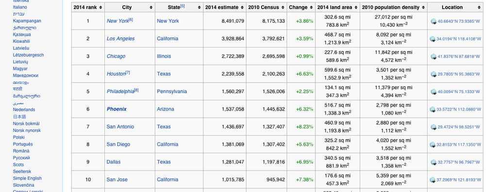

### Three main scenarios

2. Data in unstructured format

[figure not shown]

www.ipaidabribe.com/reports/paid

### Three main scenarios

3. Data hidden behind web forms

[figure not shown]

[Candidates on 2015 Venezuelan parliamentary election](http://eligetucandidato.org/filtro/)

### Three main scenarios

1. Data in table format
   - Automatic extraction with `rvest`
2. Data in unstructured format
   - Element identification with `selectorGadget`
   - Aumatic extraction with `rvest`
3. Data hidden behind web forms
   - Automation of web browser behavior with `selenium`

### Web data in table format

[figure not shown]

[Population by Age Groups and Sex, U.S. Census](http://www.census.gov/population/international/data/idb/region.php?N=%20Results%20&T=10&A=separate&RT=0&Y=2016&R=-1&C=US)

### APIs

API = Application Programming Interface; a set of structured https requests that return data in JSON or XML format.

Types of APIs:  
1. RESTful APIs: queries for static information at current moment (e.g. user profiles, posts, etc.)  
2. Streaming APIs: changes in users' data in real time (e.g. new tweets, new FB posts…)

Most APIs are rate-limited:

- Restrictions on number of API calls by user/IP address and period of time.

### Connecting with an API

Constructing a REST API call:

- Baseline URL: `https://graph.facebook.com/`
- Parameters: `?ids=barackobama,johnmccain`
- Authentication token: `&access_token=XXXXX`

Response is often in JSON Format.

Authentication

- Most common is an open standard called OAuth
- Connections without sharing username or password, only temporary tokens that can be refreshed
- `httr` package in R implements most cases ([examples](https://github.com/hadley/httr/tree/master/demo))

### Social media APIs

Twitter:

1. REST API:
   - Data about user profiles, friends and followers, and recent tweets
   - R packages: `twitteR` or `smappR`
2. Streaming API:
   - “Stream” of tweets as they are being published
   - Filter by: 1) by keywords, 2) by location, 3) random sampling
   - R package: `streamR`

Facebook:

- Graph API: data from public Facebook pages (posts, likes, comments)
- R package: `Rfacebook`

### Other APIs

[CRAN Web Technologies Task View](https://cran.r-project.org/web/views/WebTechnologies.html)